# 学习R

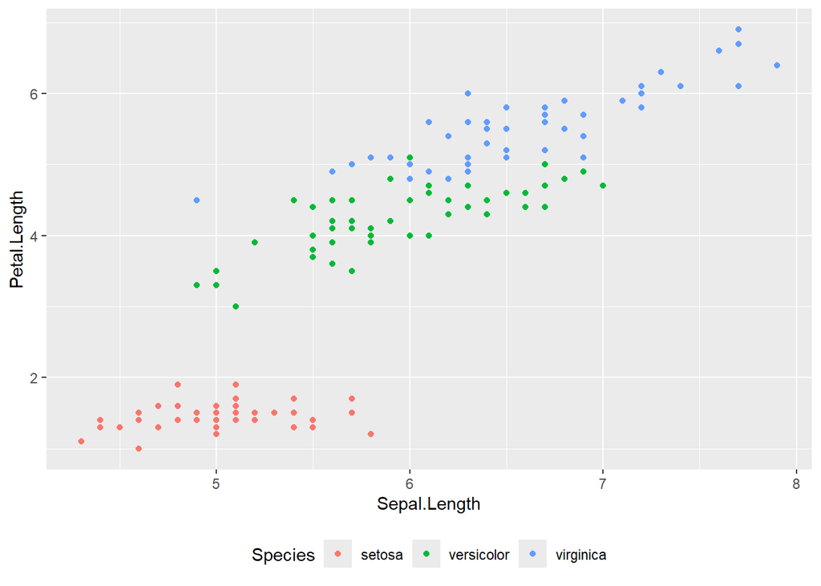

```r
pic + theme(legend.position="bottom")  # 图例在底部
```

更改图例的字体样式

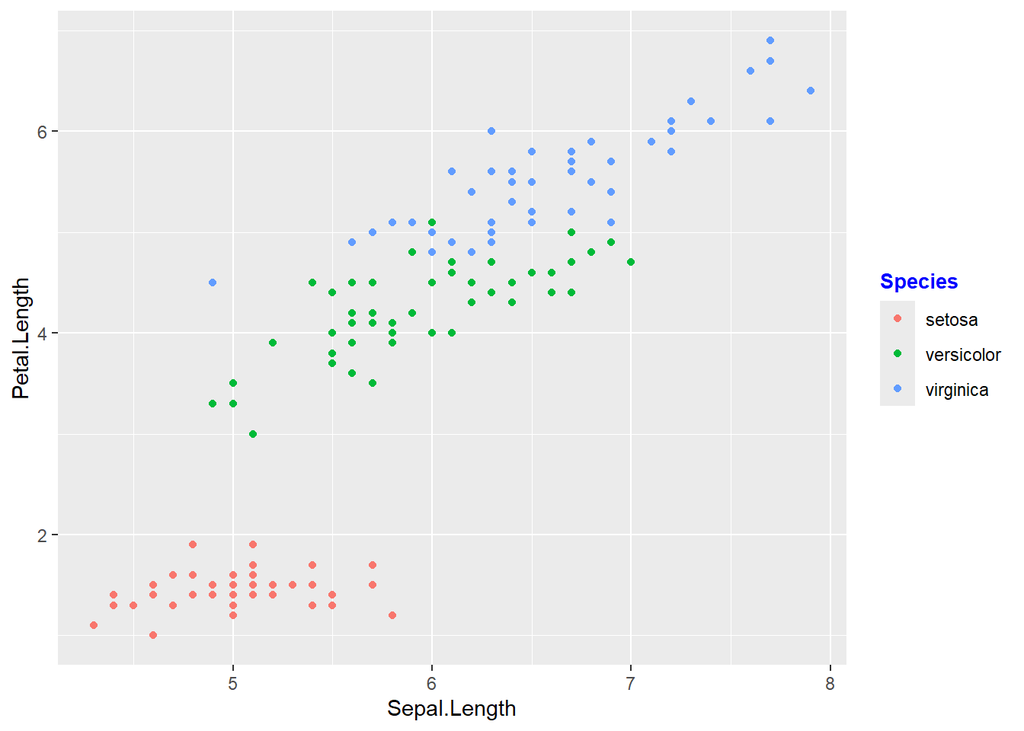

```r
# 更改图例标题和文本字体样式
# 图例标题
pic + theme(legend.title = element_text(colour = "blue",  # 图例名称颜色
                                        size = 10,  face = "bold"))
```

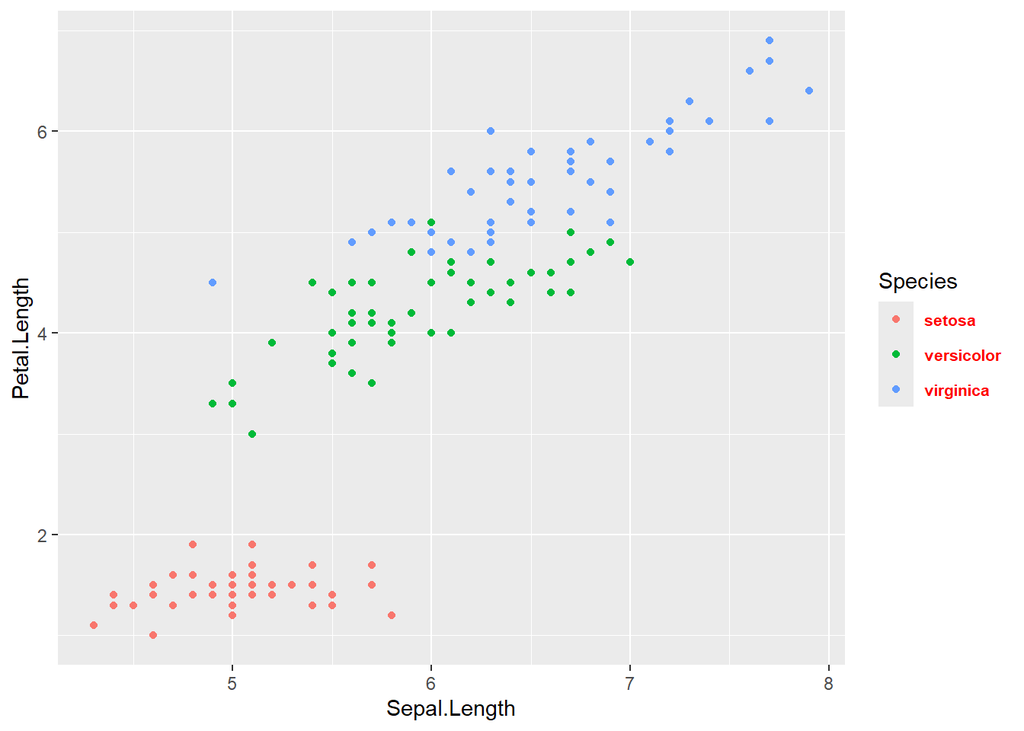

```r
# 图例标签
pic + theme(legend.text = element_text(colour = "red", # 图例标签的颜色
                                       size = 8,  face = "bold"))
```

ggplot2绘制散点图

散点图显示一个变量与另一个变量的关联程度。变量之间的关系称为相关性，通常用于统计方法

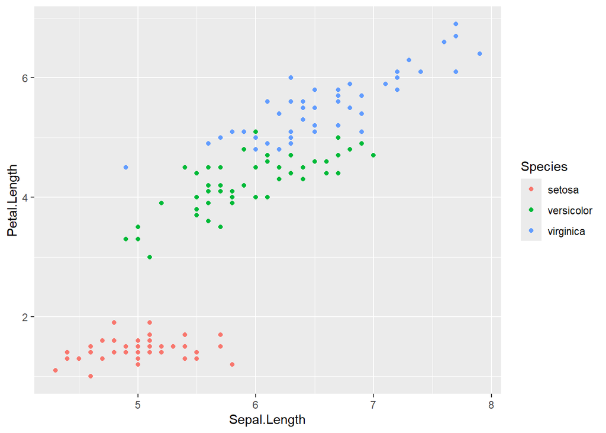

```r
# 以iris为例

pic_iris <- ggplot(iris,aes(Sepal.Length,Petal.Length,
                            colour = Species)) + # colour 为点添加颜色
  geom_point() # 绘制散点图

pic_iris
```

使用 geom_point() 函数中名为 shape 的属性来更改点的形状

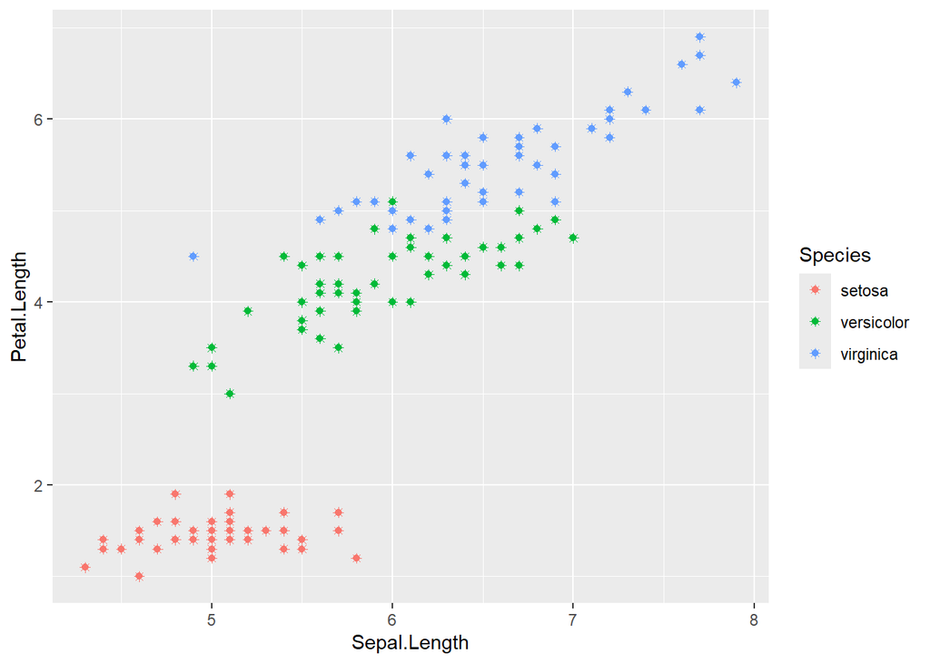

```r
# 修改点的形状
pic_iris + geom_point(shape = 8)
```

建立变量之间的关系。

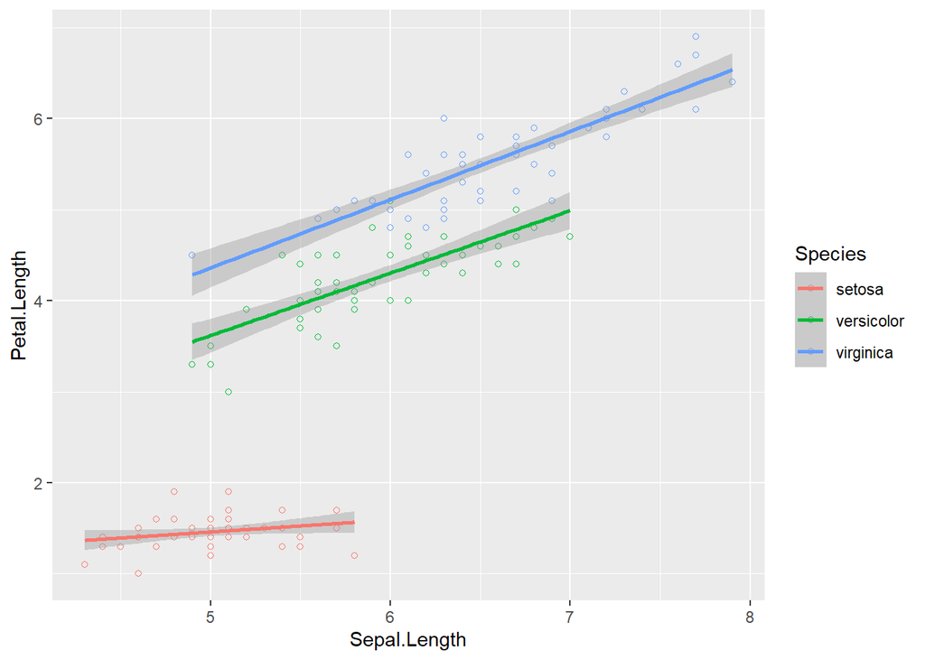

```r
# 使用geom_smooth函数的属性方法，使用lm方法，添加回归线
ggplot(iris, aes(Sepal.Length, Petal.Length, colour=Species)) +
  geom_point(shape=1) +
  geom_smooth(method=lm) # 有助于重叠模式和创建所需变量的模式
```

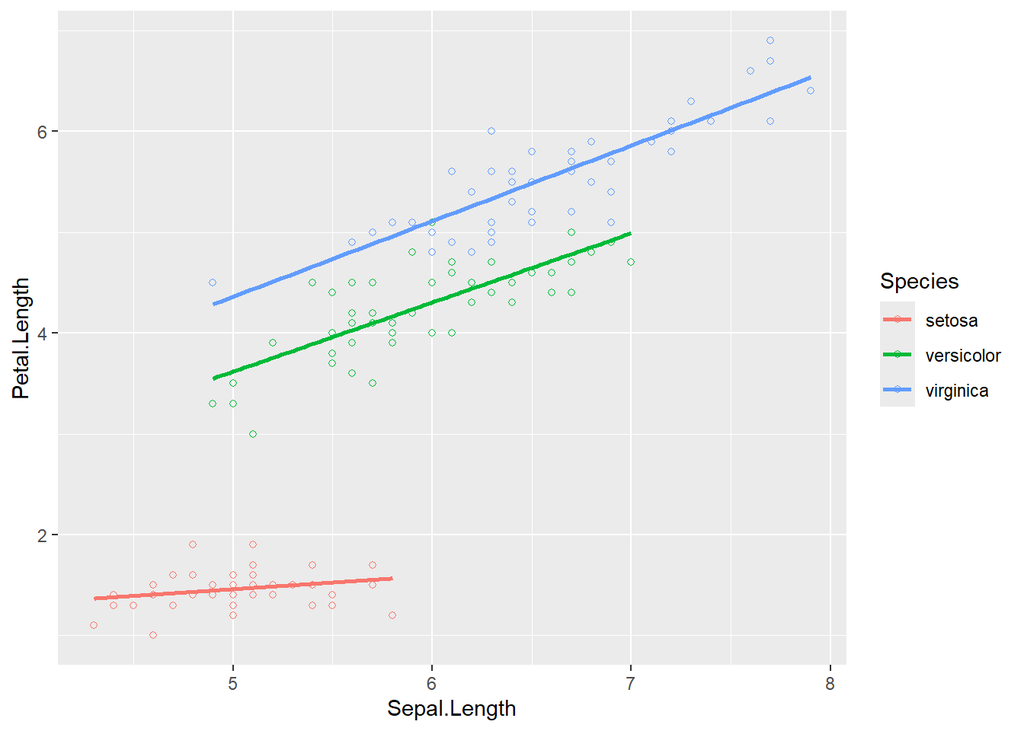

```r
# 使用geom_smooth函数的属性方法，使用lm方法，添加回归线
ggplot(iris, aes(Sepal.Length, Petal.Length, colour=Species)) +
  geom_point(shape=1) +
  geom_smooth(method=lm,se = F) # 传入参数se = F
```

ggplot2绘制抖动图

抖动图包括可以描绘散点图的特殊效果。抖动只不过是一个随机值，它被分配给点以将它们分开

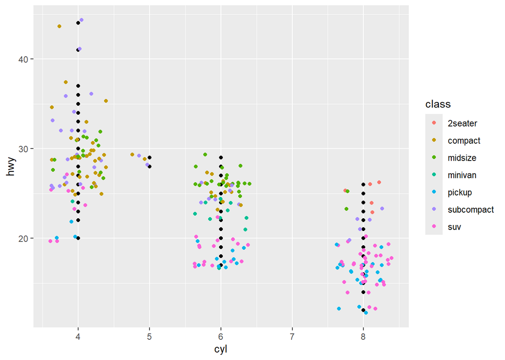

```r
ggplot(mpg, aes(cyl, hwy)) +
  geom_point() +
  geom_jitter(aes(colour = class))
```

ggplot2绘制条形图和直方图，计数图主要表现形式

条形图以矩形方式表示分类数据。条形可以垂直和水平绘制。高度或长度与图形中表示的值成比例。条形图的 x 轴和 y 轴指定包含在特定数据集中的类别。

直方图是一种条形图，它表示原始数据，并清晰地显示所述数据集的分布情况。

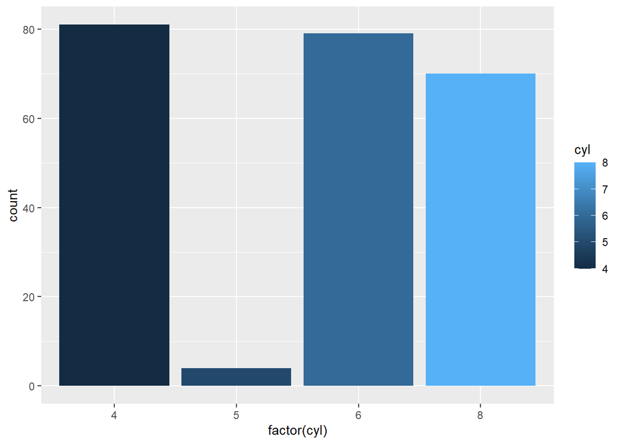

```r
# 条形计数图
p <- ggplot(mpg,aes(x = factor(cyl),fill = cyl)) +
  geom_bar()  # 创建条形图，它采用称为计数的统计值属性。
p
```

直方图

geom_histogram() 包含创建直方图所需的所有属性

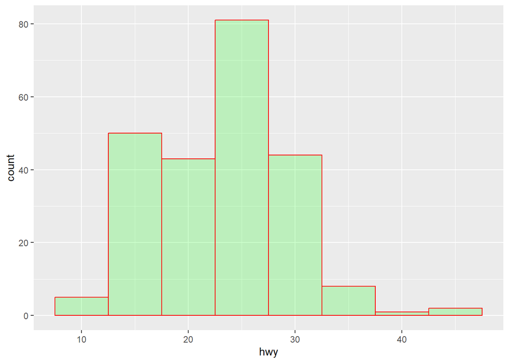

```r
 # 直方图计数图
ggplot(data=mpg, aes(x=hwy)) +
    geom_histogram( col="red",  # 线条颜色
       fill="green",    # 填充颜色
       alpha = .2,
       binwidth = 5)
```

ggplot2绘制饼图

饼图被视为圆形统计图，被分成多个切片来表示数值比例。

创建饼图

```r
# 加载模块
library(ggplot2)

# 来源：频率表
df <- as.data.frame(table(mpg$class))  # 对mpg的class列的列联表，并转化为数据框
colnames(df) <- c("class", "freq")
print(df)
```

```
##        class freq
## 1    2seater    5
## 2    compact   47
## 3    midsize   41
## 4    minivan   11
## 5     pickup   33
## 6 subcompact   35
## 7        suv   62
```

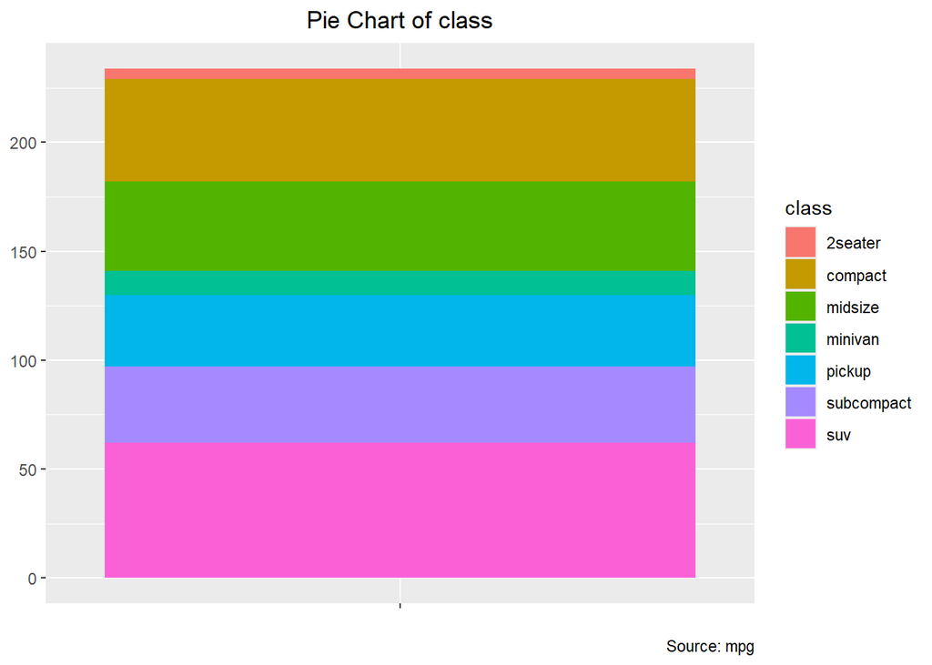

```r
pie <- ggplot(df, aes(x = "", y=freq, fill = factor(class))) +
  geom_bar(width = 1, stat = "identity") +
  theme(axis.line = element_blank(),
     plot.title = element_text(hjust=0.5)) +
     labs(fill="class",
        x=NULL,
       y=NULL,
        title="Pie Chart of class", # 图片名
        caption="Source: mpg")  # 注释
pie
```

创建所需的饼图

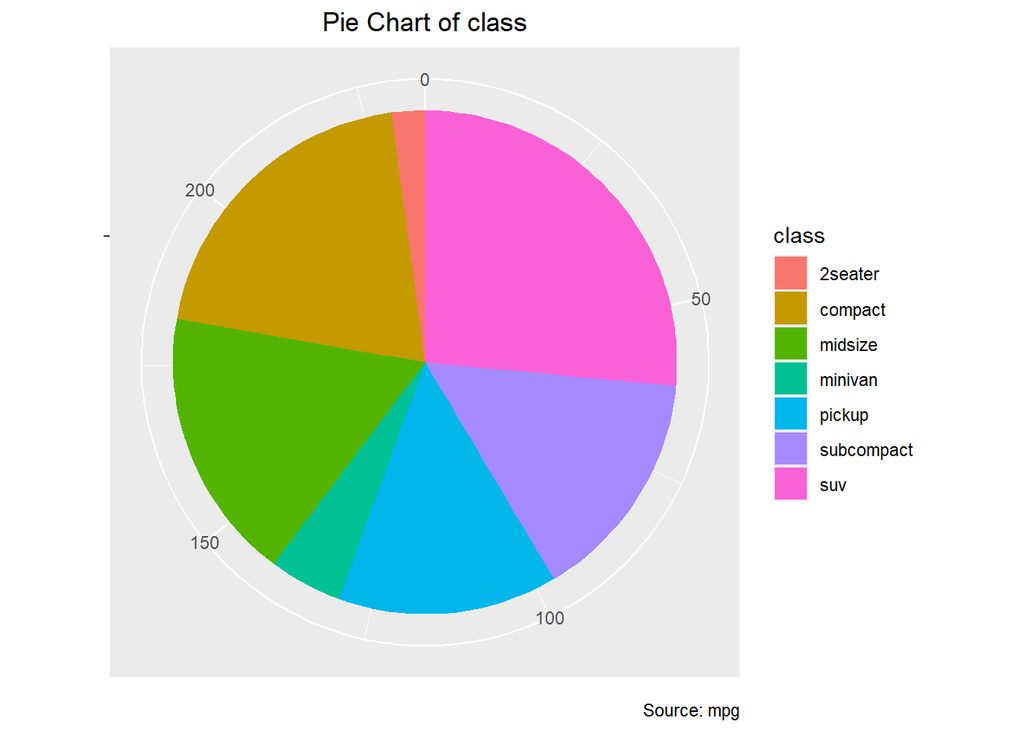

```r
pie + coord_polar(theta = "y", start=0)
```

# ggplot2 - 边际图

边际图用于评估两个变量之间的关系并检查它们的分布。当我们谈到创建边际图时，它们只不过是在各自的 x 轴和 y 轴边缘具有直方图、箱线图或点图的散点图。

使用包”ggExtra”在 R 中创建边际图

```r
library(ggplot2,ggExtra)

head(mpg)
```

```
## # A tibble: 6 × 11
##   manufacturer model displ  year   cyl trans      drv     cty   hwy fl    class
##   <chr>        <chr> <dbl> <int> <int> <chr>      <chr> <int> <int> <chr> <chr>
## 1 audi         a4      1.8  1999     4 auto(l5)   f        18    29 p     compa…
## 2 audi         a4      1.8  1999     4 manual(m5) f        21    29 p     compa…
## 3 audi         a4      2    2008     4 manual(m6) f        20    31 p     compa…
## 4 audi         a4      2    2008     4 auto(av)   f        21    30 p     compa…
## 5 audi         a4      2.8  1999     6 auto(l5)   f        16    26 p     compa…
## 6 audi         a4      2.8  1999     6 manual(m5) f        18    26 p     compa…
```

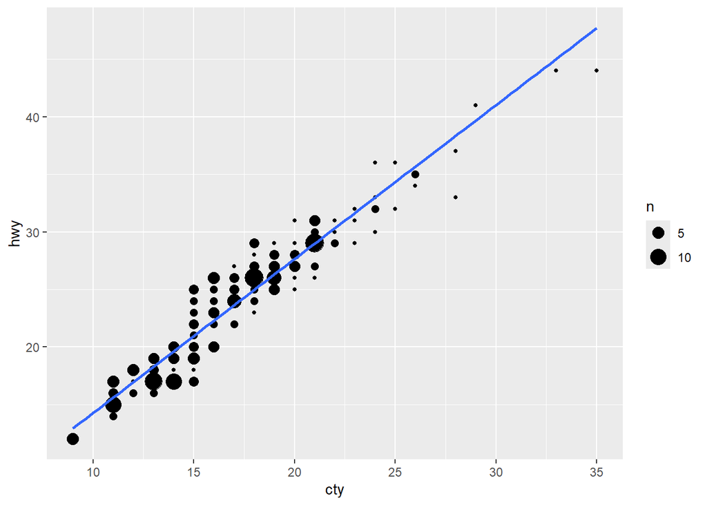

```r
# 绘图
mpg_pic <- ggplot(mpg,aes(x = cty,y = hwy)) +
  geom_count()+
  geom_smooth(method = 'lm',se = F)

mpg_pic
```

使用 ggMarginal 函数创建边际图，这有助于生成两个属性”hwy”和”cty”之间的关系。

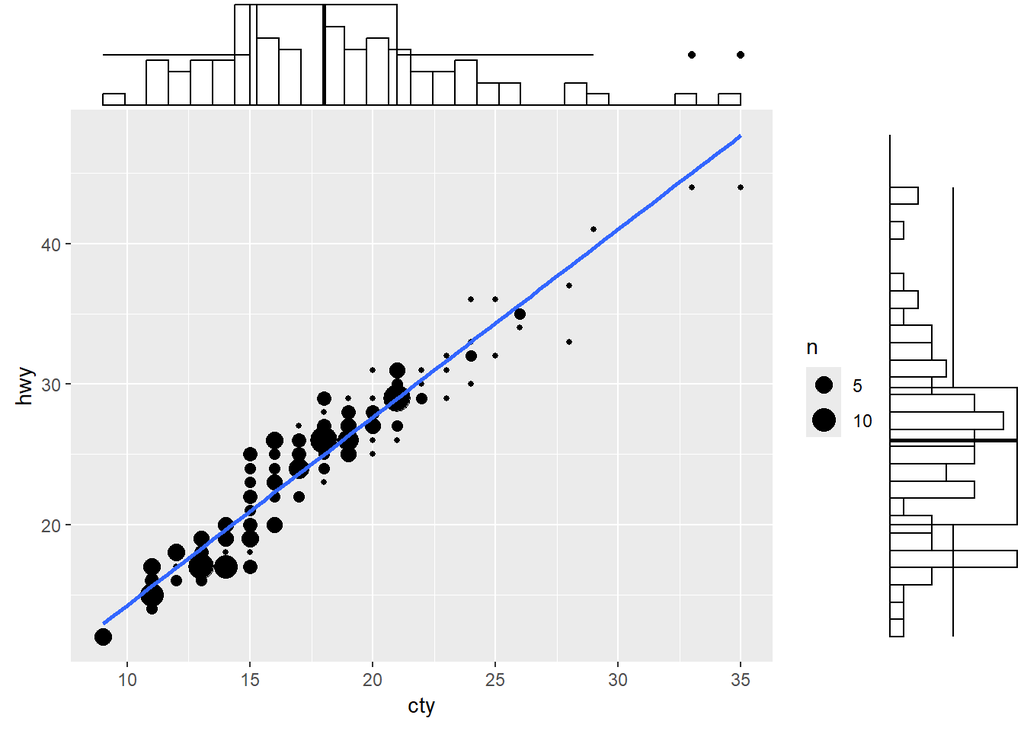

```r
library(ggExtra)
ggMarginal(mpg_pic, type = "histogram", fill="transparent")  # 添加边际直方图
ggMarginal(mpg_pic, type = "boxplot", fill="transparent")   # 添加边际箱图
```

# ggplot2 - 气泡图

气泡图其实就是散点图，它基本上是一个散点图，第三个数值变量用于表示圆圈大小。

绘制气泡图

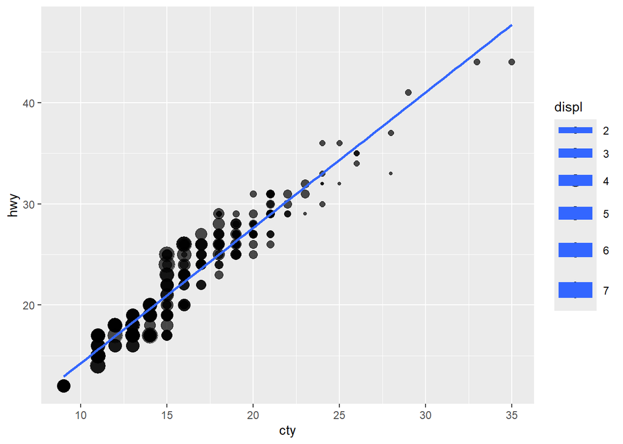

```r
ggplot(mpg, aes(x=cty, y=hwy, size = displ)) + # size表示依据size的值定义气泡大小
  geom_point(alpha=0.7)+
  geom_smooth(method = 'lm',se = F)
```

# ggplot2 - 发散图

```r
#Load ggplot
library(ggplot2)

# 为汽车名称创建新列
mtcars$`car name` <- rownames(mtcars)

# 计算标准化的 mtacrs
mtcars$mpg_z <- round((mtcars$mpg - mean(mtcars$mpg))/sd(mtcars$mpg), 2)

# 高于/低于平均值标志
mtcars$mpg_type <- ifelse(mtcars$mpg_z < 0, "below", "above")

# sort
mtcars <- mtcars[order(mtcars$mpg_z), ]

mtcars
```

```
##                      mpg cyl  disp  hp drat    wt  qsec vs am gear carb
## Cadillac Fleetwood  10.4   8 472.0 205 2.93 5.250 17.98  0  0    3    4
## Lincoln Continental 10.4   8 460.0 215 3.00 5.424 17.82  0  0    3    4
## Camaro Z28          13.3   8 350.0 245 3.73 3.840 15.41  0  0    3    4
## Duster 360          14.3   8 360.0 245 3.21 3.570 15.84  0  0    3    4
## Chrysler Imperial   14.7   8 440.0 230 3.23 5.345 17.42  0  0    3    4
## Maserati Bora       15.0   8 301.0 335 3.54 3.570 14.60  0  1    5    8
## Merc 450SLC         15.2   8 275.8 180 3.07 3.780 18.00  0  0    3    3
## AMC Javelin         15.2   8 304.0 150 3.15 3.435 17.30  0  0    3    2
## Dodge Challenger    15.5   8 318.0 150 2.76 3.520 16.87  0  0    3    2
## Ford Pantera L      15.8   8 351.0 264 4.22 3.170 14.50  0  1    5    4
## Merc 450SE          16.4   8 275.8 180 3.07 4.070 17.40  0  0    3    3
## Merc 450SL          17.3   8 275.8 180 3.07 3.730 17.60  0  0    3    3
## Merc 280C           17.8   6 167.6 123 3.92 3.440 18.90  1  0    4    4
## Valiant             18.1   6 225.0 105 2.76 3.460 20.22  1  0    3    1
## Hornet Sportabout   18.7   8 360.0 175 3.15 3.440 17.02  0  0    3    2
## Merc 280            19.2   6 167.6 123 3.92 3.440 18.30  1  0    4    4
## Pontiac Firebird    19.2   8 400.0 175 3.08 3.845 17.05  0  0    3    2
## Ferrari Dino        19.7   6 145.0 175 3.62 2.770 15.50  0  1    5    6
## Mazda RX4           21.0   6 160.0 110 3.90 2.620 16.46  0  1    4    4
## Mazda RX4 Wag       21.0   6 160.0 110 3.90 2.875 17.02  0  1    4    4
## Hornet 4 Drive      21.4   6 258.0 110 3.08 3.215 19.44  1  0    3    1
## Volvo 142E          21.4   4 121.0 109 4.11 2.780 18.60  1  1    4    2
## Toyota Corona       21.5   4 120.1  97 3.70 2.465 20.01  1  0    3    1
## Datsun 710          22.8   4 108.0  93 3.85 2.320 18.61  1  1    4    1
## Merc 230            22.8   4 140.8  95 3.92 3.150 22.90  1  0    4    2
## Merc 240D           24.4   4 146.7  62 3.69 3.190 20.00  1  0    4    2
## Porsche 914-2       26.0   4 120.3  91 4.43 2.140 16.70  0  1    5    2
## Fiat X1-9           27.3   4  79.0  66 4.08 1.935 18.90  1  1    4    1
## Honda Civic         30.4   4  75.7  52 4.93 1.615 18.52  1  1    4    2
## Lotus Europa        30.4   4  95.1 113 3.77 1.513 16.90  1  1    5    2
## Fiat 128            32.4   4  78.7  66 4.08 2.200 19.47  1  1    4    1
## Toyota Corolla      33.9   4  71.1  65 4.22 1.835 19.90  1  1    4    1
##                                car name mpg_z mpg_type
## Cadillac Fleetwood   Cadillac Fleetwood -1.61    below
## Lincoln Continental Lincoln Continental -1.61    below
## Camaro Z28                   Camaro Z28 -1.13    below
## Duster 360                   Duster 360 -0.96    below
## Chrysler Imperial     Chrysler Imperial -0.89    below
## Maserati Bora             Maserati Bora -0.84    below
```

[output cut: 11 more lines]

```
## Ferrari Dino               Ferrari Dino -0.06    below
## Mazda RX4                     Mazda RX4  0.15    above
## Mazda RX4 Wag             Mazda RX4 Wag  0.15    above
## Hornet 4 Drive           Hornet 4 Drive  0.22    above
## Volvo 142E                   Volvo 142E  0.22    above
## Toyota Corona             Toyota Corona  0.23    above
## Datsun 710                   Datsun 710  0.45    above
## Merc 230                       Merc 230  0.45    above
## Merc 240D                     Merc 240D  0.72    above
## Porsche 914-2             Porsche 914-2  0.98    above
## Fiat X1-9                     Fiat X1-9  1.20    above
## Honda Civic                 Honda Civic  1.71    above
## Lotus Europa               Lotus Europa  1.71    above
## Fiat 128                       Fiat 128  2.04    above
## Toyota Corolla           Toyota Corolla  2.29    above
```

将值转换为因子以保留特定图中的排序顺序

```r
# 转换为因子以保留图中的排序顺序。
mtcars$`car name` <- factor(mtcars$`car name`, levels = mtcars$`car name`)
```

创建条形图

散条形图标记了一些维度成员相对于所述值指向向上或向下的方向。

发散条形图的输出如下所示，我们使用函数 geom_bar 来创建条形图

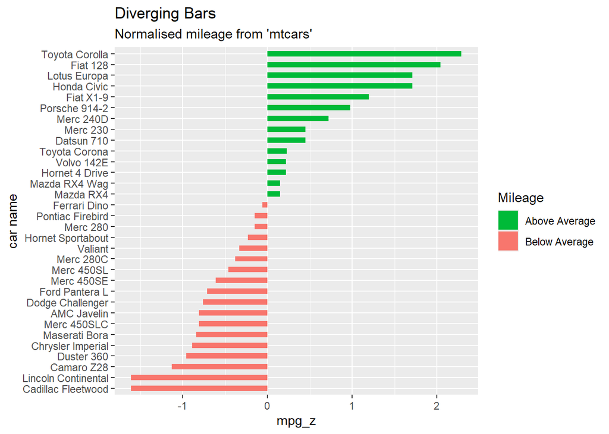

```r
# 发散的条形图
ggplot(mtcars, aes(x=`car name`, y=mpg_z, label=mpg_z)) +
  geom_bar(stat='identity', aes(fill=mpg_type), width=.5) +
  scale_fill_manual(name="Mileage",
     labels = c("Above Average", "Below Average"),
     values = c("above"="#00ba38", "below"="#f8766d")) +
 labs(subtitle="Normalised mileage from 'mtcars'",
     title= "Diverging Bars") +
  coord_flip()
```

发散帮帮糖图

只需更改要使用的函数，即 geom_segment()，它有助于创建棒棒糖图。

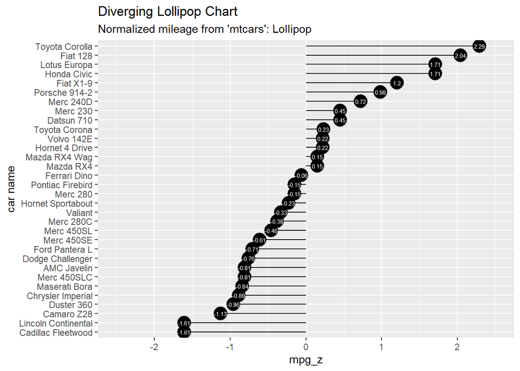

```r
ggplot(mtcars, aes(x=`car name`, y=mpg_z, label=mpg_z)) +
 geom_point(stat='identity', fill="black", size=6) +
 geom_segment(aes(y = 0,
    x = `car name`,
    yend = mpg_z,
    xend = `car name`),
       color = "black") +
 geom_text(color="white", size=2) +
 labs(title="Diverging Lollipop Chart",
    subtitle="Normalized mileage from 'mtcars': Lollipop") +
 ylim(-2.5, 2.5) +
 coord_flip()
```

密度图

密度图是上述数据集中任何数值变量分布的图形表示。它使用核密度估计来显示变量的概率密度函数。

“ggplot2”包包含一个名为 geom_density() 的函数来创建密度图。

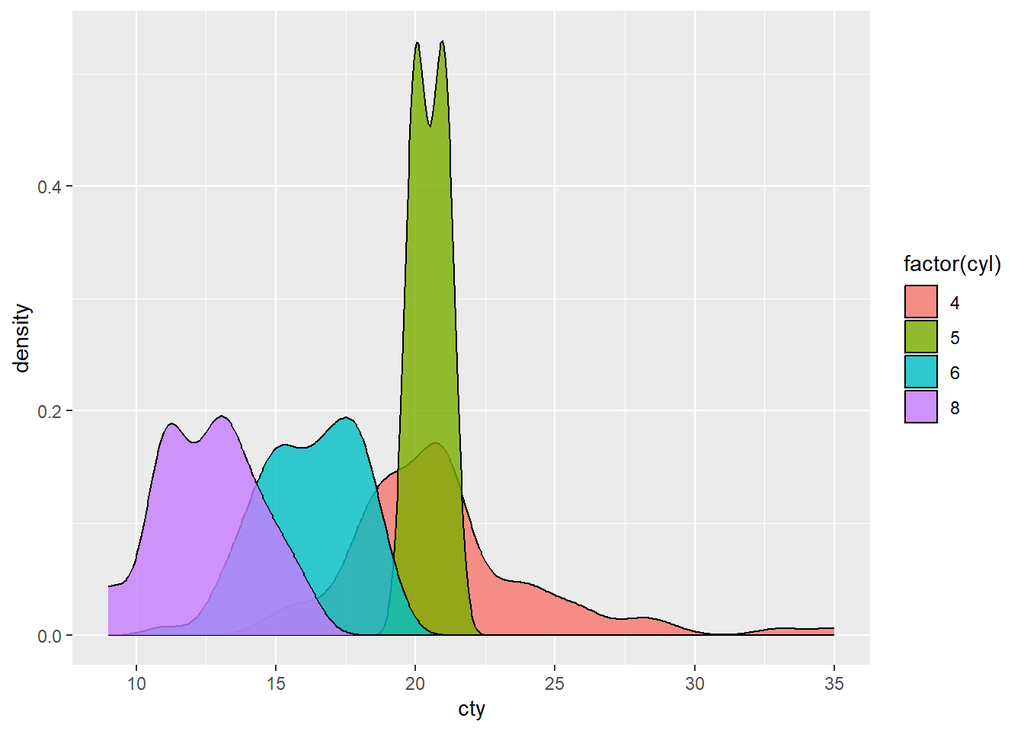

```r
p <- ggplot(mpg, aes(cty)) +
  geom_density(aes(fill=factor(cyl)), alpha=0.8)
 p
```

箱线图

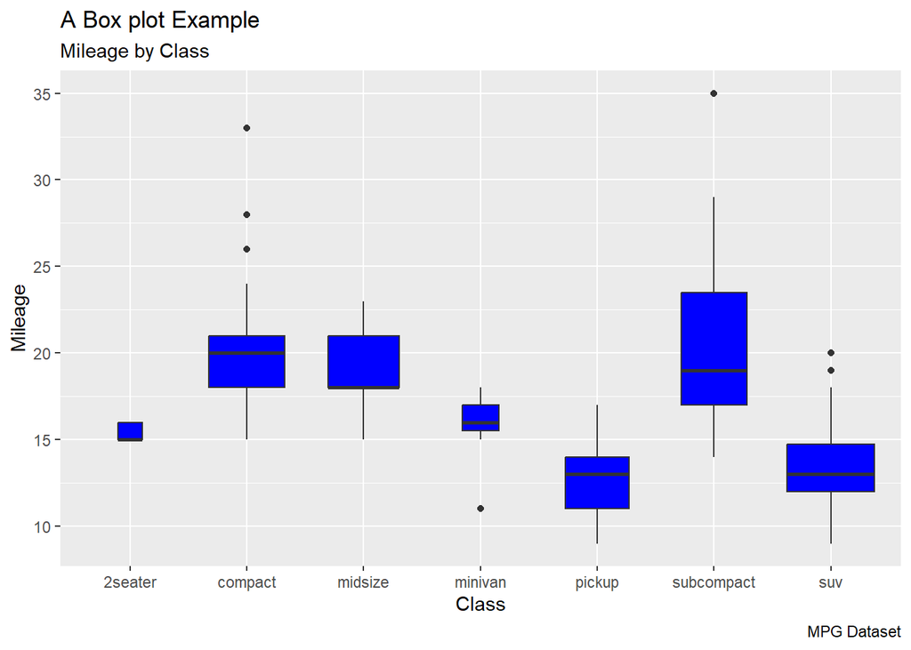

```r
p <- ggplot(mpg, aes(class, cty)) +
  geom_boxplot(varwidth=T, fill="blue")
p + labs(title="A Box plot Example",
    subtitle="Mileage by Class",
    caption="MPG Dataset",
    x="Class",
    y="Mileage")
```

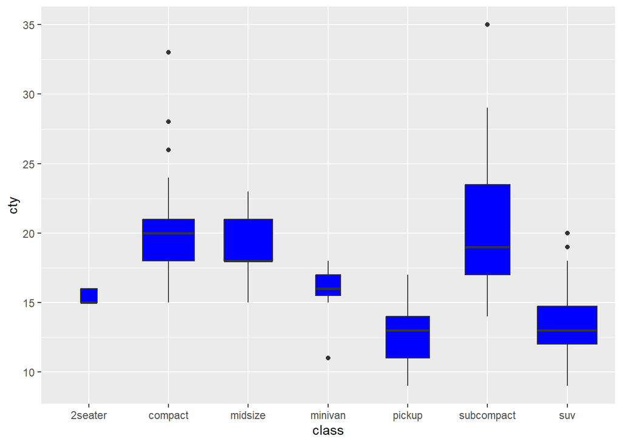

```r
p
```

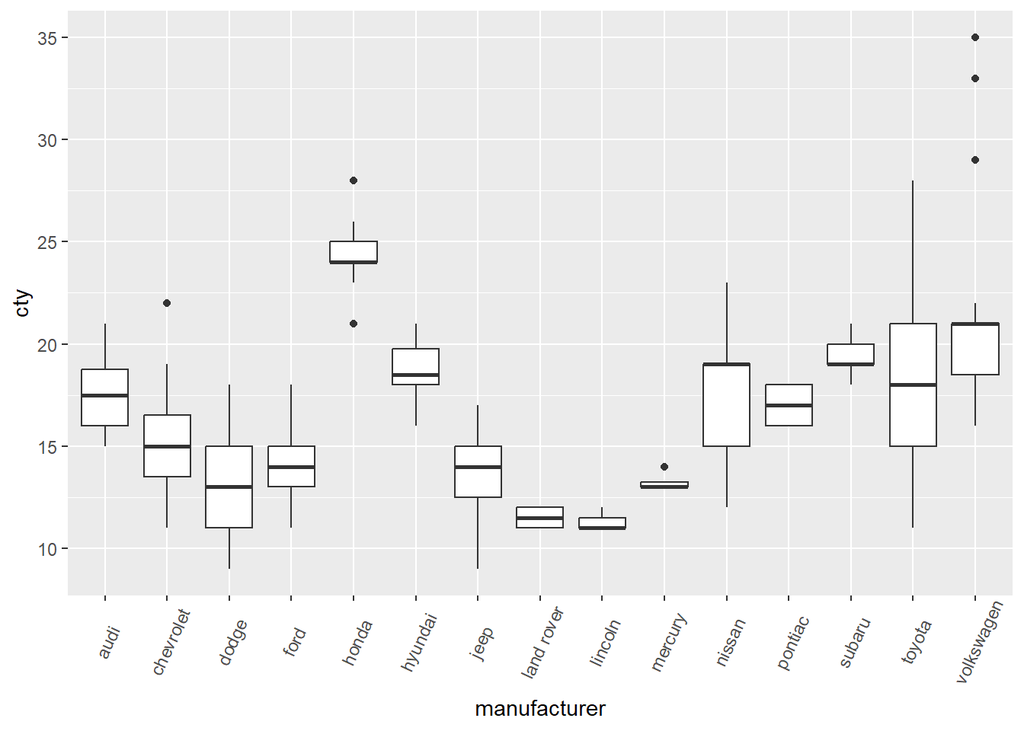

```r
p <- ggplot(mpg, aes(manufacturer, cty)) +
 geom_boxplot() +
 theme(axis.text.x = element_text(angle=65, vjust=0.6))
p
```

小提琴图

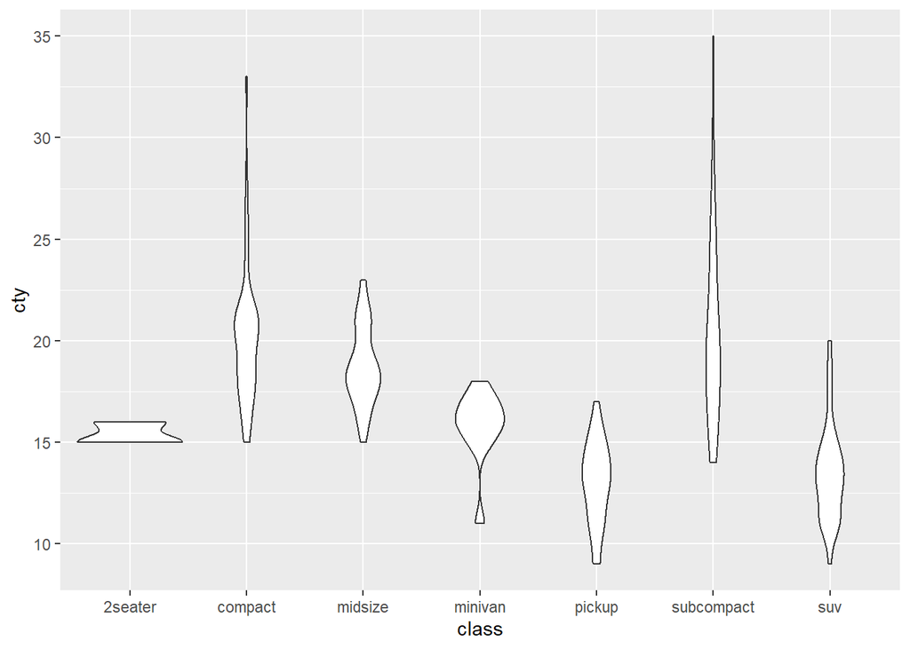

```r
p <- ggplot(mpg, aes(class, cty))

p + geom_violin()
```

设置背景颜色

命令更改背景颜色，这有助于更改面板 (panel.background) −

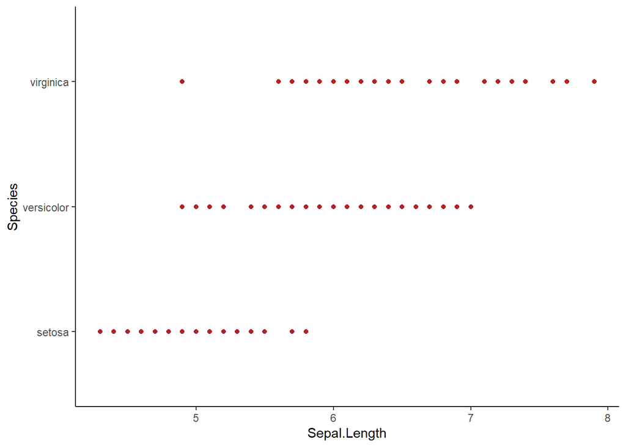

```r
ggplot(iris, aes(Sepal.Length, Species))+
  geom_point(color="firebrick")+
 theme(panel.background = element_rect(fill = 'white'),
       axis.line = element_line(color = 'black'))
```

## 6、R数据清洗

```r
library(readxl)
files <- "A:\\Rstudio\\学习R\\学习R_数据\\第九批_AF.xlsx"

dt <- read_excel(files)

head(dt,5)
```

```
## # A tibble: 5 × 5
##   image_id index ID       label      detection
##   <chr>    <chr> <chr>    <chr>      <chr>
## 1 图像_01  1a    HS120597 HS120597_1 42
## 2 图像_01  1b    HS120597 HS120597_2 52
## 3 图像_01  1c    HS120597 HS120597_3 61
## 4 图像_01  1d    HS120597 HS120597_4 60
## 5 图像_01  1e    HS120597 HS120597_5 54
```

删除含有缺失值的行

```r
library(dplyr)
dt_omit <- dt %>% na.omit()
```

删除重复行

```r
dt_repeat <- dt_omit %>% distinct(.keep_all = T)
```

删除某列中值为NaN的行

```r
dt_repeat
```

```
## # A tibble: 428 × 5
##    image_id index ID       label      detection
##    <chr>    <chr> <chr>    <chr>      <chr>
##  1 图像_01  1a    HS120597 HS120597_1 42
##  2 图像_01  1b    HS120597 HS120597_2 52
##  3 图像_01  1c    HS120597 HS120597_3 61
##  4 图像_01  1d    HS120597 HS120597_4 60
##  5 图像_01  1e    HS120597 HS120597_5 54
##  6 图像_02  2a    HS120599 HS120599_1 210
##  7 图像_02  2b    HS120599 HS120599_2 126
##  8 图像_02  2c    HS120599 HS120599_3 162
##  9 图像_02  2d    HS120599 HS120599_4 209
## 10 图像_02  2e    HS120599 HS120599_5 146
## # ℹ 418 more rows
```

```r
# 删除某列中值为NaN的行
dt_clear <- dt_repeat %>%
  filter(detection != 'NaN')

#同时 删除某列中值为NaN、a的行
dt_clear <- dt_repeat %>%
  filter(detection %in% c('a','NaN'))  # detection为列名
```

一个Excel文件多个sheet一次性读取，存为列表，方便访问、批处理

以A:\学习R_数据下的rna_seq.xlsx文件为例

```r
path = 'A:\\Rstudio\\学习R\\学习R_数据'
setwd(path)

library(rio)

# 读取所有Sheet到列表
RNA_seq <- import_list("RNA_seq.xlsx")

# 自动命名列表元素（Sheet名）
names(RNA_seq) <- excel_sheets("RNA_seq.xlsx")
```

将一个excel的多个sheet横向合并,**指定列**

如果多个Sheet需要按某一列（如样本ID）对齐后再横向合并：

```r
path = 'A:\\Rstudio\\学习R\\学习R_数据'
setwd(path)

# 加载包
library(readxl)
library(dplyr)
library(purrr)
```

```r
file <- 'RNA_seq.xlsx'

# 1. 读取Excel中的所有Sheet名称
sheet_names <- excel_sheets(file)

# 2. 读取所有Sheet到列表
RNA_dt <- map(sheet_names, ~ read_excel(file, sheet = .x))

# 假设所有Sheet都有"ID"列
merged_data <- reduce(RNA_dt, ~ full_join(.x, .y, by = "gene_id"))

# 或使用左连接（以第一个Sheet的ID为准）,只保留第一个sheet的ID，其他sheet的ID删除
merged_data <- reduce(RNA_dt, ~ left_join(.x, .y, by = "gene_id"))

head(merged_data)
```

```
## # A tibble: 6 × 5
##   gene_id   chicken_liver_A_counts chicken_liver_B_counts chicken_muscle_A_cou…¹
##   <chr>                      <dbl>                  <dbl>                  <dbl>
## 1 ENSGALG0…                      1                      3                      3
## 2 ENSGALG0…                    366                    609                   1162
## 3 ENSGALG0…                      0                      0                      0
## 4 ENSGALG0…                      0                      0                      0
## 5 ENSGALG0…                     36                     30                    167
## 6 ENSGALG0…                   1740                   2414                   4007
## # ℹ abbreviated name: ¹chicken_muscle_A_counts
## # ℹ 1 more variable: chicken_muscle_B_counts <dbl>
```

合并两个数据框，指定列

```r
data_1 <- head(RNA_seq$chicken_liver_A_counts,10)
data_2 <- head(RNA_seq$chicken_muscle_A_counts,15)
```

保留两个数据框中关键列匹配的行

```r
library(dplyr)

# 按指定列（如"ID"）合并，仅保留共有的行
data_same <- inner_join(data_1, data_2, by = "gene_id")

# 多列作为关键列
# merged_data <- inner_join(data_1, data_2, by = c("ID", "Date"))

head(data_same)
```

```
##              gene_id chicken_liver_A_counts chicken_muscle_A_counts
## 1 ENSGALG00000000003                      1                       3
## 2 ENSGALG00000000011                    366                    1162
## 3 ENSGALG00000000038                      0                       0
## 4 ENSGALG00000000044                      0                       0
## 5 ENSGALG00000000048                     36                     167
## 6 ENSGALG00000000055                   1740                    4007
```

**保留左边**数据框的所有行，匹配右边数据框的列，只保留df1有的行

```r
# 保留df1的所有行，df2无匹配时填充NA
data_all_1 <- left_join(data_1,data_2,by = 'gene_id')
head(data_all_1)
```

```
##              gene_id chicken_liver_A_counts chicken_muscle_A_counts
## 1 ENSGALG00000000003                      1                       3
## 2 ENSGALG00000000011                    366                    1162
## 3 ENSGALG00000000038                      0                       0
## 4 ENSGALG00000000044                      0                       0
## 5 ENSGALG00000000048                     36                     167
## 6 ENSGALG00000000055                   1740                    4007
```

保留两个数据框的所有行，无匹配时填充NA

```r
data_all <- full_join(data_1,data_2,by = 'gene_id')
head(data_all,15)
```

```
##               gene_id chicken_liver_A_counts chicken_muscle_A_counts
## 1  ENSGALG00000000003                      1                       3
## 2  ENSGALG00000000011                    366                    1162
## 3  ENSGALG00000000038                      0                       0
## 4  ENSGALG00000000044                      0                       0
## 5  ENSGALG00000000048                     36                     167
## 6  ENSGALG00000000055                   1740                    4007
## 7  ENSGALG00000000059                      8                       6
## 8  ENSGALG00000000067                   3818                     105
## 9  ENSGALG00000000071                    130                     130
## 10 ENSGALG00000000081                     19                       2
## 11 ENSGALG00000000086                     NA                    5473
## 12 ENSGALG00000000091                     NA                     874
## 13 ENSGALG00000000094                     NA                    3194
## 14 ENSGALG00000000102                     NA                      17
## 15 ENSGALG00000000104                     NA                      43
```

**保留右边**数据框的所有行，匹配左边数据框的列,Na填充左边没有

```r
data_all_2 <- right_join(data_1,data_2,by = 'gene_id')
head(data_all_2,15)
```

```
##               gene_id chicken_liver_A_counts chicken_muscle_A_counts
## 1  ENSGALG00000000003                      1                       3
## 2  ENSGALG00000000011                    366                    1162
## 3  ENSGALG00000000038                      0                       0
## 4  ENSGALG00000000044                      0                       0
## 5  ENSGALG00000000048                     36                     167
## 6  ENSGALG00000000055                   1740                    4007
## 7  ENSGALG00000000059                      8                       6
## 8  ENSGALG00000000067                   3818                     105
## 9  ENSGALG00000000071                    130                     130
## 10 ENSGALG00000000081                     19                       2
## 11 ENSGALG00000000086                     NA                    5473
## 12 ENSGALG00000000091                     NA                     874
## 13 ENSGALG00000000094                     NA                    3194
## 14 ENSGALG00000000102                     NA                      17
## 15 ENSGALG00000000104                     NA                      43
```

保留左边数据框中与右边匹配的行，不合并右边列，保留左边数据框中出现在右边的行

```r
# 筛选df1中存在于df2的行
filtered_data <- semi_join(data_1,data_2,by = 'gene_id')
```

保留左边数据框中与右边不匹配的行

```r
# 筛选df1中不存在于df2的行
filtered_data_a <- anti_join(data_2,data_1,by = 'gene_id')
```

选出某列的值为a的行

```r
library(tidyr)
head(iris)
```

```
##   Sepal.Length Sepal.Width Petal.Length Petal.Width Species
## 1          5.1         3.5          1.4         0.2  setosa
## 2          4.9         3.0          1.4         0.2  setosa
## 3          4.7         3.2          1.3         0.2  setosa
## 4          4.6         3.1          1.5         0.2  setosa
## 5          5.0         3.6          1.4         0.2  setosa
## 6          5.4         3.9          1.7         0.4  setosa
```

```r
setosa <- iris %>%
  filter(Species == 'setosa')  # 筛选出species列中是setosa的行
setosa
```

```
##    Sepal.Length Sepal.Width Petal.Length Petal.Width Species
## 1           5.1         3.5          1.4         0.2  setosa
## 2           4.9         3.0          1.4         0.2  setosa
## 3           4.7         3.2          1.3         0.2  setosa
## 4           4.6         3.1          1.5         0.2  setosa
## 5           5.0         3.6          1.4         0.2  setosa
## 6           5.4         3.9          1.7         0.4  setosa
## 7           4.6         3.4          1.4         0.3  setosa
## 8           5.0         3.4          1.5         0.2  setosa
## 9           4.4         2.9          1.4         0.2  setosa
## 10          4.9         3.1          1.5         0.1  setosa
## 11          5.4         3.7          1.5         0.2  setosa
## 12          4.8         3.4          1.6         0.2  setosa
## 13          4.8         3.0          1.4         0.1  setosa
## 14          4.3         3.0          1.1         0.1  setosa
```

[output cut: 36 more lines]

根据某列的值的大小范围进行筛选

```r
head(iris)
```

```
##   Sepal.Length Sepal.Width Petal.Length Petal.Width Species
## 1          5.1         3.5          1.4         0.2  setosa
## 2          4.9         3.0          1.4         0.2  setosa
## 3          4.7         3.2          1.3         0.2  setosa
## 4          4.6         3.1          1.5         0.2  setosa
## 5          5.0         3.6          1.4         0.2  setosa
## 6          5.4         3.9          1.7         0.4  setosa
```

```r
petal_len_less <- iris %>%
  filter(Petal.Length < 1.5)  # 筛选Petal.Length小于1.5的行

nrow(petal_len_less)
```

```
## [1] 24
```